# Boston Bluebikes Data Exploration and Visualization

## Preliminary Wrangling

1. Dropped unnecessary columns *start station id*, *start station latitude*, *start station longitude*, *end station id*, *end station latitude*, *end station longitude* and *bikeid*.
2. Replace space in column names with underline.
3. Changed data type of *starttime* and *stoptime* to datetime
4. Replace gender column values: 0=Female, 1=Male, 2=Other
5. Changed data type of *usertype* and *gender* to category

```python
# import all packages and set plots to be embedded inline
import numpy as np
import pandas as pd
import matplotlib.pyplot as plt
import seaborn as sb
import statsmodels.api as sm

%matplotlib inline
```

```python
# load datasets and append them together
df1 = pd.read_csv('201904-bluebikes-tripdata.csv')
df2 = pd.read_csv('201905-bluebikes-tripdata.csv')
df3 = pd.read_csv('201907-bluebikes.tripdata.csv')
df = df1.append(df2).append(df3)
df.shape
```

```
(663800, 15)
```

```python
df.head(1)
```

|  | tripduration | starttime | stoptime | start station id | start station name | start station latitude | start station longitude | end station id | end station name | end station latitude | end station longitude | bikeid | usertype | birth year | gender |
| --- | --- | --- | --- | --- | --- | --- | --- | --- | --- | --- | --- | --- | --- | --- | --- |
| 0 | 3363 | 2019-04-01 00:04:38.1400 | 2019-04-01 01:00:41.6390 | 8 | Union Square - Brighton Ave at Cambridge St | 42.353334 | -71.137313 | 8 | Union Square - Brighton Ave at Cambridge St | 42.353334 | -71.137313 | 3736 | Customer | 1969 | 0 |

```python
# drop unnecessary columns
df.drop(columns=['start station id', 'start station latitude', 'start station longitude', 'end station id',
                 'end station latitude', 'end station longitude', 'bikeid'], inplace=True)
df.head(1)
```

|  | tripduration | starttime | stoptime | start station name | end station name | usertype | birth year | gender |
| --- | --- | --- | --- | --- | --- | --- | --- | --- |
| 0 | 3363 | 2019-04-01 00:04:38.1400 | 2019-04-01 01:00:41.6390 | Union Square - Brighton Ave at Cambridge St | Union Square - Brighton Ave at Cambridge St | Customer | 1969 | 0 |

```python
# replace space in column names with underline
col_names = []
for i in range(len(df.columns)):
    name = df.columns[i].replace(' ', '_')
    col_names.append(name)

df.columns = col_names
df.head(1)
```

|  | tripduration | starttime | stoptime | start_station_name | end_station_name | usertype | birth_year | gender |
| --- | --- | --- | --- | --- | --- | --- | --- | --- |
| 0 | 3363 | 2019-04-01 00:04:38.1400 | 2019-04-01 01:00:41.6390 | Union Square - Brighton Ave at Cambridge St | Union Square - Brighton Ave at Cambridge St | Customer | 1969 | 0 |

```python
df.info()
```

```
<class 'pandas.core.frame.DataFrame'>
Int64Index: 663800 entries, 0 to 274021
Data columns (total 8 columns):
tripduration          663800 non-null int64
starttime             663800 non-null object
stoptime              663800 non-null object
start_station_name    663800 non-null object
end_station_name      663800 non-null object
usertype              663800 non-null object
birth_year            663800 non-null int64
gender                663800 non-null int64
dtypes: int64(3), object(5)
memory usage: 45.6+ MB
```

```python
# change data type of starttime and stoptime to datetime
df['starttime'] = pd.to_datetime(df['starttime'])
df['stoptime'] = pd.to_datetime(df['stoptime'])
```

```python
# change gender column values: 0=Female, 1=Male, 2=Other
gender = {0: 'Female', 1: 'Male', 2: 'Other'}
df['gender'].replace(gender, inplace=True)
df.head()
```

|  | tripduration | starttime | stoptime | start_station_name | end_station_name | usertype | birth_year | gender |
| --- | --- | --- | --- | --- | --- | --- | --- | --- |
| 0 | 3363 | 2019-04-01 00:04:38.140 | 2019-04-01 01:00:41.639 | Union Square - Brighton Ave at Cambridge St | Union Square - Brighton Ave at Cambridge St | Customer | 1969 | Female |
| 1 | 1206 | 2019-04-01 00:06:40.003 | 2019-04-01 00:26:46.102 | Harvard University / SEAS Cruft-Pierce Halls a... | Allston Green District - Griggs St at Commonwe... | Customer | 1993 | Male |
| 2 | 123 | 2019-04-01 00:07:15.580 | 2019-04-01 00:09:18.764 | University Park | Central Square at Mass Ave / Essex St | Subscriber | 1990 | Male |
| 3 | 2056 | 2019-04-01 00:11:03.279 | 2019-04-01 00:45:19.891 | Seaport Blvd at Sleeper St | Harvard Law School at Mass Ave / Jarvis St | Subscriber | 1969 | Male |
| 4 | 165 | 2019-04-01 00:13:56.836 | 2019-04-01 00:16:42.068 | Harvard University Gund Hall at Quincy St / Ki... | Beacon St at Washington / Kirkland | Subscriber | 1988 | Male |

```python
# change data type of usertype and gender to category
df['usertype'] = pd.Categorical(df['usertype'], categories=['Subscriber', 'Customer'], ordered=True)
df['gender'] = pd.Categorical(df['gender'], categories=['Female', 'Male', 'Other'], ordered=True)
df.dtypes
```

```
tripduration                   int64
starttime             datetime64[ns]
stoptime              datetime64[ns]
start_station_name            object
end_station_name              object
usertype                    category
birth_year                     int64
gender                      category
dtype: object
```

```python
# save clean data to file
df.to_csv('clean-bluebikes-tripdata.csv')
```

### What is the structure of your dataset?

There are 663,800 individual rides in this dataset with 8 features:

- tripduration in sec
- starttime
- stoptime
- start station name
- end station name
- usertype
- birth year
- gender

### What is/are the main feature(s) of interest in your dataset?

I want to profile Boston Bluebikes users' biking habits by analyzing their demographics and bike usage. This can help to decide if the current pricing strategy should be improved and find potential business opportunities.

### What features in the dataset do you think will help support your investigation into your feature(s) of interest?

There are two types of user: subscribers are annual or monthly members; customers are single trip or day pass users.

To start with, I want to get users' demographics, including **birth year distribution** and **gender distribution**.

Second, I want to identify the differences of biking habits between subscribers and customers. I will analyze their bike usage, including **count of rides and ride duration, by hour and by weekday**.

Finally, I want to find the **top 10 start stations, end stations and routes by each type of user**.

## Univariate Exploration

First of all, I want to plot a pie chart to see the proportion of each user type.

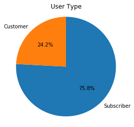

```python
sorted_counts = df['usertype'].value_counts()
plt.pie(sorted_counts, labels=sorted_counts.index, autopct='%1.1f%%', startangle=90, counterclock=False)
plt.axis('square')
plt.title('User Type');
```

Next up, I want to plot histograms to see all users' birth year distribution and gender distribution.

```python
df['birth_year'].describe()
```

```
count    663800.000000
mean       1983.757730
std          11.613985
min        1886.000000
25%        1973.000000
50%        1988.000000
75%        1993.000000
max        2003.000000
Name: birth_year, dtype: float64
```

It is weired that some users were born before 1900. As I know, the longest human lifespan is 122 years. I need to dig further to see how many users are over 100 years old.

```python
centenarian = df[df.birth_year <= 1919]
centenarian.birth_year.value_counts()
```

```
1900    40
1904    16
1901    11
1888     6
1886     3
1907     1
Name: birth_year, dtype: int64
```

Most "centenarians" were born in 1900. It might be a default set that many users did not change and others may be typos or wrong inputs. I will exclude those data.

```python
df = df[df.birth_year > 1919]
```

```python
# add a birth_decade column
bins = np.arange(1920, df.birth_year.max()+10, 10)
labels = [str(x)+'s' for x in bins[:-1]]
df['birth_decade'] = pd.cut(df.birth_year, bins=bins, labels=labels, right=False, include_lowest=True)
df.head()
```

|  | tripduration | starttime | stoptime | start_station_name | end_station_name | usertype | birth_year | gender | birth_decade |
| --- | --- | --- | --- | --- | --- | --- | --- | --- | --- |
| 0 | 3363 | 2019-04-01 00:04:38.140 | 2019-04-01 01:00:41.639 | Union Square - Brighton Ave at Cambridge St | Union Square - Brighton Ave at Cambridge St | Customer | 1969 | Female | 1960s |
| 1 | 1206 | 2019-04-01 00:06:40.003 | 2019-04-01 00:26:46.102 | Harvard University / SEAS Cruft-Pierce Halls a... | Allston Green District - Griggs St at Commonwe... | Customer | 1993 | Male | 1990s |
| 2 | 123 | 2019-04-01 00:07:15.580 | 2019-04-01 00:09:18.764 | University Park | Central Square at Mass Ave / Essex St | Subscriber | 1990 | Male | 1990s |
| 3 | 2056 | 2019-04-01 00:11:03.279 | 2019-04-01 00:45:19.891 | Seaport Blvd at Sleeper St | Harvard Law School at Mass Ave / Jarvis St | Subscriber | 1969 | Male | 1960s |
| 4 | 165 | 2019-04-01 00:13:56.836 | 2019-04-01 00:16:42.068 | Harvard University Gund Hall at Quincy St / Ki... | Beacon St at Washington / Kirkland | Subscriber | 1988 | Male | 1980s |

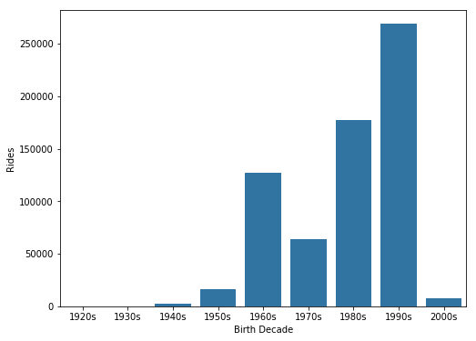

```python
# plot a histogram for birth decade distribution
plt.figure(figsize=[8, 6])
base_color = sb.color_palette()[0]

ax = sb.countplot(data=df, x='birth_decade', color=base_color)
ax.set(xlabel='Birth Decade', ylabel='Rides');
```

**The majority of users were born in 80s and 90s and many were born in 60s**. It looks like no user was born in 20s and 30s. I will double check. If no one was born in 20s and 30s, I will remove the tick labels.

```python
seniors = df[df.birth_year.between(1920, 1939)]
seniors.birth_year.value_counts()
```

```
1935    23
1939    19
1937    10
1933     9
1929     9
1938     2
1936     2
Name: birth_year, dtype: int64
```

There are only a few users who were born in 20s and 30s so I can hardly see them in the bar chart. This is reasonable because seniors may not use bikes very often. I will keep the tick labels.

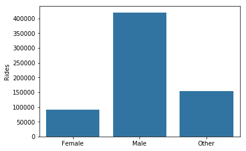

```python
# plot a histogram for gender distribution
sb.countplot(data=df, x='gender', color=base_color)
plt.xlabel('')
plt.ylabel('Rides');
```

**The majority of users are male**. I thought maybe male is a default set but actually female is the first choice so the data is valid. A lot of users identify their gender as "other". There is no way to know if it is because they do not want to provide gender information or they identify themselves as gender neutral. To better analyze gender data, there should be more choices for users to pick like "Do not want to provide".

Next, I want to plot histograms to see counts of rides by hour and by weekday.

```python
# extract hour from start time
df['hour'] = df['starttime'].dt.hour

# extract weekday from start time with Monday=0, Sunday=6
df['weekday'] = df['starttime'].dt.weekday
df.head(1)
```

|  | tripduration | starttime | stoptime | start_station_name | end_station_name | usertype | birth_year | gender | birth_decade | hour | weekday |
| --- | --- | --- | --- | --- | --- | --- | --- | --- | --- | --- | --- |
| 0 | 3363 | 2019-04-01 00:04:38.140 | 2019-04-01 01:00:41.639 | Union Square - Brighton Ave at Cambridge St | Union Square - Brighton Ave at Cambridge St | Customer | 1969 | Female | 1960s | 0 | 0 |

```python
# change weekday column values to weekday names
weekday = {0: 'Monday', 1: 'Tuesday', 2: 'Wednesday', 3: 'Thursday', 4: 'Friday', 5: 'Saturday', 6: 'Sunday'}
df['weekday'].replace(weekday, inplace=True)
df.head()
```

|  | tripduration | starttime | stoptime | start_station_name | end_station_name | usertype | birth_year | gender | birth_decade | hour | weekday |
| --- | --- | --- | --- | --- | --- | --- | --- | --- | --- | --- | --- |
| 0 | 3363 | 2019-04-01 00:04:38.140 | 2019-04-01 01:00:41.639 | Union Square - Brighton Ave at Cambridge St | Union Square - Brighton Ave at Cambridge St | Customer | 1969 | Female | 1960s | 0 | Monday |
| 1 | 1206 | 2019-04-01 00:06:40.003 | 2019-04-01 00:26:46.102 | Harvard University / SEAS Cruft-Pierce Halls a... | Allston Green District - Griggs St at Commonwe... | Customer | 1993 | Male | 1990s | 0 | Monday |
| 2 | 123 | 2019-04-01 00:07:15.580 | 2019-04-01 00:09:18.764 | University Park | Central Square at Mass Ave / Essex St | Subscriber | 1990 | Male | 1990s | 0 | Monday |
| 3 | 2056 | 2019-04-01 00:11:03.279 | 2019-04-01 00:45:19.891 | Seaport Blvd at Sleeper St | Harvard Law School at Mass Ave / Jarvis St | Subscriber | 1969 | Male | 1960s | 0 | Monday |
| 4 | 165 | 2019-04-01 00:13:56.836 | 2019-04-01 00:16:42.068 | Harvard University Gund Hall at Quincy St / Ki... | Beacon St at Washington / Kirkland | Subscriber | 1988 | Male | 1980s | 0 | Monday |

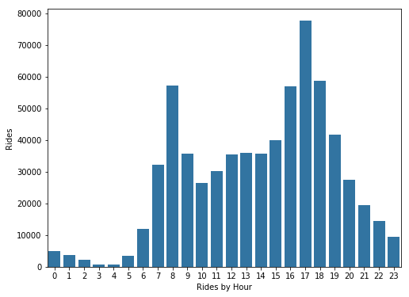

```python
# plot a histogram to see count of rides by hour
plt.figure(figsize=[8, 6])

sb.countplot(data=df, x='hour', color=base_color)
plt.xlabel('Rides by Hour')
plt.ylabel('Rides');
```

**It is a bimodal shape with two peaks at 8am and 5pm**. Compared to morning peak, bike demand was higher in the evening between 4-6pm. This is reasonable because many people may ride bikes for dinner, shopping and leisure other than going home during this time. This is more like a weekday pattern. I will plot count of rides distribution using weekday data and weekend data repectively.

```python
# create a df_weekday and a df_weekend DataFrame
df_weekday = df[(df.weekday != 'Saturday') & (df.weekday != 'Sunday')]
df_weekend = df[(df.weekday == 'Saturday') | (df.weekday == 'Sunday')]
```

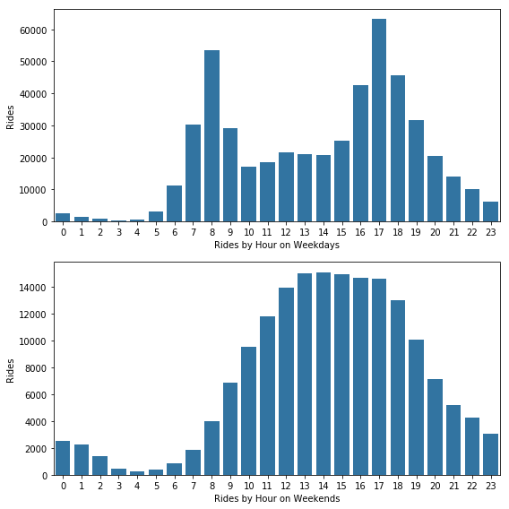

```python
fig, ax = plt.subplots(nrows=2, figsize = [8, 8])

sb.countplot(data=df_weekday, x='hour', color=base_color, ax=ax[0])
ax[0].set_xlabel('Rides by Hour on Weekdays')
ax[0].set_ylabel('Rides')

sb.countplot(data=df_weekend, x='hour', color=base_color, ax=ax[1])
ax[1].set_xlabel('Rides by Hour on Weekends')
ax[1].set_ylabel('Rides')

plt.tight_layout();
```

**The weekday data is still a bimodal shape but the weekend data is more like a bell shape**. This indicates that people use bikes primarily for work on weekdays and for leisure on weekends.

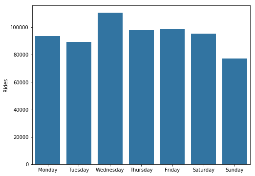

```python
# plot a histogram to see count of rides by weekday
plt.figure(figsize=[8, 6])

sb.countplot(data=df, x='weekday', color=base_color)
plt.xlabel('')
plt.ylabel('Rides');
```

It is interesting to see that bike demand does not change dramatically over weekdays with a small peak on Wednesday and slightly down on Sunday. This deserves further investigation in the next section.

Next, I want to plot a histogram to see ride duration distribution. When I first plotted the histogram, there were many outliers on the right. To better view the result, I split the data to short rides that are less than 1 hour and long rides that are over 1 hour. I also create new columns to show ride duration as "0-5", "5-10" etc.

```python
# create a duration_min column
df['duration_min'] = df.tripduration/60
df['duration_min'] = df['duration_min'].astype(int)

# create a df_short DataFrame
df_short = df[df.duration_min < 60]

bins = np.arange(0, df_short.duration_min.max()+5, 5)
labels = [str(x) + '-' + str(x+5) for x in bins[:-1]]
df_short['interval_min'] = pd.cut(df_short.duration_min, bins=bins, labels=labels,
                                  right=False, include_lowest=True)
df_short.head(1)
```

|  | tripduration | starttime | stoptime | start_station_name | end_station_name | usertype | birth_year | gender | birth_decade | hour | weekday | duration_min | interval_min |
| --- | --- | --- | --- | --- | --- | --- | --- | --- | --- | --- | --- | --- | --- |
| 0 | 3363 | 2019-04-01 00:04:38.140 | 2019-04-01 01:00:41.639 | Union Square - Brighton Ave at Cambridge St | Union Square - Brighton Ave at Cambridge St | Customer | 1969 | Female | 1960s | 0 | Monday | 56 | 55-60 |

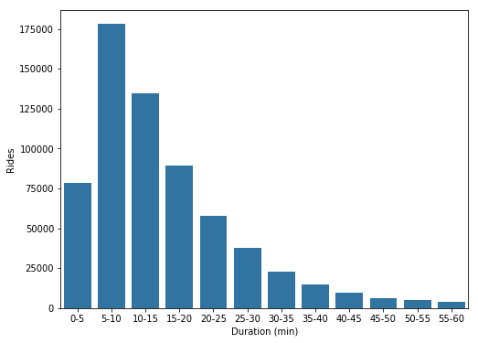

```python
plt.figure(figsize=[8, 6])

ax = sb.countplot(data=df_short, x='interval_min', color=base_color)
ax.set(xlabel='Duration (min)', ylabel='Rides');
```

**The majority of users take rides for 5-20 minutes, no more than 30 minutes**. This is probably due to the bike rental policy that a single ride is limited to 30 minutes for customers and 45 minutes for members. Otherwise, an extra fee will be applied.

According to Bluebikes's pricing, customers can have unlimited access to a 2-hour ride in a 24-hour period. I assume most of the long rides would fall into the 1-2 hour category.

```python
# create a duration_h column
df['duration_h'] = df['duration_min']/60
df['duration_h'] = df['duration_h'].astype(int)

# create a df_long DataFrame
df_long = df[(df.duration_h >= 1) & (df.duration_h < 24)]

bins = np.arange(1, 25, 1)
labels = [str(x) + '-' + str(x+1) for x in bins[:-1]]
df_long['interval_h'] = pd.cut(df_long.duration_h, bins=bins, labels=labels,
                               right=False, include_lowest=True)
df_long.head(1)
```

|  | tripduration | starttime | stoptime | start_station_name | end_station_name | usertype | birth_year | gender | birth_decade | hour | weekday | duration_min | duration_h | interval_h |
| --- | --- | --- | --- | --- | --- | --- | --- | --- | --- | --- | --- | --- | --- | --- |
| 236 | 45491 | 2019-04-01 07:25:50.715 | 2019-04-01 20:04:02.313 | Egleston Square - Atherton St at Washington St | Egleston Square - Atherton St at Washington St | Customer | 1969 | Female | 1960s | 7 | Monday | 758 | 12 | 12-13 |

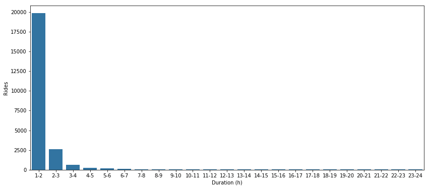

```python
plt.figure(figsize=[14, 6])

ax = sb.countplot(data=df_long, x='interval_h', color=base_color)
ax.set(xlabel='Duration (h)', ylabel='Rides');
```

As I expected, **most longer rides last no more than 2 hours**. There are 0.1% rides that last even longer than 24 hours. I assume that is due to lost of bike or forgetfulness of returning bike.

```python
# save df and df_short to file
df.to_csv('final-bluebikes.csv', index=False)
df_short.to_csv('final-bluebikes-short.csv', index=False)
df_long.to_csv('final-bluebikes-long.csv', index=False)
```

```python
df[df.duration_h >= 24].shape[0]/df.shape[0]
```

```
0.001095336458130877
```

Finally, I want to find the top 10 start stations, end stations and routes by each user type.

```python
df.query('usertype == "Subscriber"')['start_station_name'].value_counts()[:10]
```

```
MIT at Mass Ave / Amherst St                        13913
MIT Stata Center at Vassar St / Main St             12451
Central Square at Mass Ave / Essex St               11241
South Station - 700 Atlantic Ave                     9366
Kendall T                                            8676
MIT Pacific St at Purrington St                      8606
Nashua Street at Red Auerbach Way                    6819
MIT Vassar St                                        6587
One Kendall Square at Hampshire St / Portland St     6349
Harvard Square at Mass Ave/ Dunster                  5946
Name: start_station_name, dtype: int64
```

```python
df.query('usertype == "Customer"')['start_station_name'].value_counts()[:10]
```

```
Harvard Square at Mass Ave/ Dunster                            3557
Mugar Way at Beacon St                                         3290
MIT at Mass Ave / Amherst St                                   2698
Boston Public Market                                           2396
South Station - 700 Atlantic Ave                               2261
Beacon St at Massachusetts Ave                                 2107
Aquarium T Stop - 200 Atlantic Ave                             2076
Christian Science Plaza - Massachusetts Ave at Westland Ave    1948
Charles Circle - Charles St at Cambridge St                    1939
Boylston St at Jersey St                                       1899
Name: start_station_name, dtype: int64
```

```python
df.query('usertype == "Subscriber"')['end_station_name'].value_counts()[:10]
```

```
MIT Stata Center at Vassar St / Main St    14477
MIT at Mass Ave / Amherst St               12708
Central Square at Mass Ave / Essex St      11264
Nashua Street at Red Auerbach Way          10053
South Station - 700 Atlantic Ave            9515
MIT Pacific St at Purrington St             7789
Kendall T                                   7396
MIT Vassar St                               6214
Harvard Square at Mass Ave/ Dunster         5958
Washington St at Rutland St                 5598
Name: end_station_name, dtype: int64
```

```python
df.query('usertype == "Customer"')['end_station_name'].value_counts()[:10]
```

```
Harvard Square at Mass Ave/ Dunster                            3681
Mugar Way at Beacon St                                         3294
Boston Public Market                                           2536
MIT at Mass Ave / Amherst St                                   2250
Nashua Street at Red Auerbach Way                              2207
Charles Circle - Charles St at Cambridge St                    2143
Beacon St at Massachusetts Ave                                 2109
Boylston St at Jersey St                                       2055
Aquarium T Stop - 200 Atlantic Ave                             2035
Christian Science Plaza - Massachusetts Ave at Westland Ave    2017
Name: end_station_name, dtype: int64
```

```python
df['route'] = df['start_station_name'] + ' --> ' + df['end_station_name']
df.query('usertype == "Subscriber"')['route'].value_counts()[:10]
```

```
MIT Pacific St at Purrington St --> MIT Stata Center at Vassar St / Main St    1670
MIT at Mass Ave / Amherst St --> Beacon St at Massachusetts Ave                1396
Beacon St at Massachusetts Ave --> MIT at Mass Ave / Amherst St                1374
MIT Vassar St --> MIT Stata Center at Vassar St / Main St                      1230
MIT Stata Center at Vassar St / Main St --> MIT Pacific St at Purrington St    1208
MIT at Mass Ave / Amherst St --> MIT Vassar St                                 1087
Central Square at Mass Ave / Essex St --> MIT Pacific St at Purrington St       959
MIT Vassar St --> MIT at Mass Ave / Amherst St                                  909
MIT Stata Center at Vassar St / Main St --> MIT Vassar St                       901
MIT at Mass Ave / Amherst St --> Central Square at Mass Ave / Essex St          853
Name: route, dtype: int64
```

Interestingly, **all of the top 10 subscriber routes have either a start station or an end station at MIT**. I assume MIT students and employees like to use Bluebikes. But why not Harvard? They both are located at Cambridge and have easy access to Bluebikes. To dig a little deeper, I googled "MIT Bluebikes" and "Harvard Bluebikes" and found that MIT students and employees can have discounted annual membership at \$35 (regularly \\$99) while Harvard stduents and employees also have discounted annual membership but the rate is doubled at \$70. This may explain why MIT students use Bluebikes more often. This is also a signal that **a better discounted membership fee may attract more users**.

```python
df.query('usertype == "Customer"')['route'].value_counts()[:10]
```

```
Mugar Way at Beacon St --> Mugar Way at Beacon St                                                                                        833
Murphy Skating Rink - 1880 Day Blvd --> Murphy Skating Rink - 1880 Day Blvd                                                              580
Airport T Stop - Bremen St at Brooks St --> Airport T Stop - Bremen St at Brooks St                                                      400
Harvard University River Houses at DeWolfe St / Cowperthwaite St --> Harvard University River Houses at DeWolfe St / Cowperthwaite St    354
Harvard Square at Mass Ave/ Dunster --> Harvard Square at Mass Ave/ Dunster                                                              264
Boylston St at Arlington St --> Boylston St at Arlington St                                                                              258
Beacon St at Massachusetts Ave --> Beacon St at Massachusetts Ave                                                                        258
Tremont St at West St --> Tremont St at West St                                                                                          258
Aquarium T Stop - 200 Atlantic Ave --> Aquarium T Stop - 200 Atlantic Ave                                                                251
MIT at Mass Ave / Amherst St --> Harvard Square at Mass Ave/ Dunster                                                                     244
Name: route, dtype: int64
```

This result is also interesting. **Among the top 10 customer routes, 9 routes have the same start station and end station**. This indicates that customers usually return bikes at the location where they initially rent bikes. This is more like a behavior of visitors who is not familiar with the city and prefer to return bikes at the same location. I need more results to confirm this hypothesis.

### Of the features you investigated, were there any unusual distributions? Did you perform any operations on the data to tidy, adjust, or change the form of the data? If so, why did you do this?

During my analysis, I found some users are over 100 years old. After double checking, I found that those data may be typos or wrong inputs so I excluded them from my analysis.

A lot of users identify their gender as "other". This is vague information and cannot be used in my analysis.

It is interesting to see that bike usage does not vary dramatically over a week which deserves further investigation in the next section when I consider user type.

When I first plotted the duration histogram there were many outliers on the right. To better view the result, I split the data into two DataFrames, short_ride (< 1 hour) and long_ride (>= 1 hour). There are 0.1% of rides that are over 24 hours which I think is probably due to lost of bike or forgetfulness of return. I would suggest Bluebikes set up a reminder in the app to remind users to return bikes on time. If they lose the bike, the reminder will help them to report the issue so that Bluebikes can track the lost bike immediately.

After analyzing the most popular routes of subscribers and customers, **I would profile subscribers as commuters and customers as visitors**, but I need more results to confirm this hypothesis.

## Bivariate Exploration

First of all, I want to see birth decade distribution and gender distribution by user type.

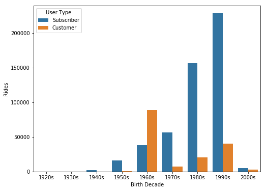

```python
plt.figure(figsize=[8, 6])

ax = sb.countplot(data=df, x='birth_decade', hue='usertype')
ax.set(xlabel='Birth Decade', ylabel='Rides')
ax.legend(loc=2, title='User Type');
```

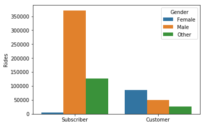

```python
ax = sb.countplot(data=df, x='usertype', hue='gender')
ax.legend(title='Gender')
ax.set(xlabel='', ylabel='Rides');
```

Interestingly, **the majority of subscribers were born in 80s and 90s while the majority of customers were born in 60s and 90s**. **The majority of subscribers are male and there are more females customers than males customers**.

Next, I want to see rides distribution by hour/weekday by user type. They both are categorical variables so a clustered bar chart is appropriate.

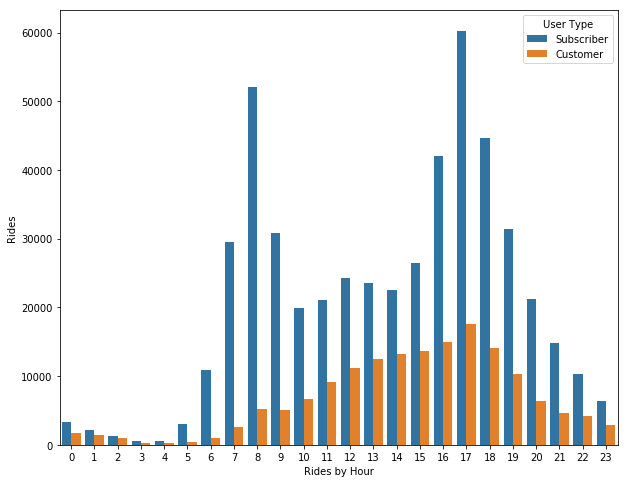

```python
plt.figure(figsize=[10, 8])

ax = sb.countplot(data=df, x='hour', hue='usertype')
ax.set_xlabel('Rides by Hour')
ax.set_ylabel('Rides')
ax.legend(title='User Type');
```

I can see that **subscribers use bikes more often during morning and evening peaks**. There is a small peak at 12pm during which I guess people use bikes to grab lunch. **The customer data increases smoothly from 11am, peaks at 5pm and then tails off**. This result further demonstrates my hypothesis that subscribers are commuters and customers are visitors.

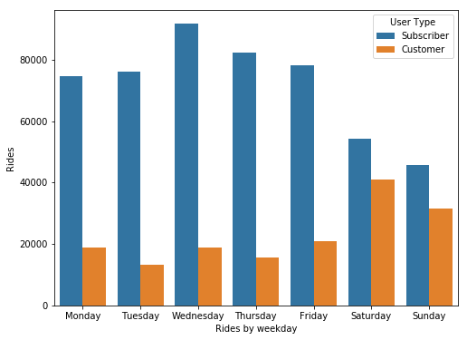

```python
plt.figure(figsize=[8, 6])

ax = sb.countplot(data=df, x='weekday', hue='usertype')
ax.set_xlabel('Rides by weekday')
ax.set_ylabel('Rides')
ax.legend(title='User Type');
```

From this chart, I can see that subscribers use bikes more often on weekdays. However, the customer data shows the opposite trend: they use bikes more often on weekends. This further indicates that **subscribers ride bikes for work while customers ride bikes for leisure**. Now I can profile subscribers and customers as:

- **Subscribers: male, born in 80s and 90s, commuters**
- **Customers: female > male, born in 60s and 90s, visitors**

Next, I want to see short ride duration distribution by user type.

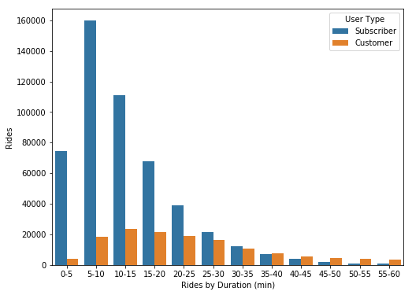

```python
plt.figure(figsize=[8, 6])

ax = sb.countplot(data=df_short, x='interval_min', hue='usertype')
ax.set_xlabel('Rides by Duration (min)')
ax.set_ylabel('Rides')
ax.legend(title='User Type');
```

This chart shows that **subscribers usually take short rides that last 5-10 minutes while customers prefer to take longer ride**. If we take 35-minute as a cut-off, we can see that more subscribers than customers take short rides on the left and more customers than subscribers take longer rides on the right. This result further demonstrates my profiling above.

The following chart is to see long ride duration distribution by user type.

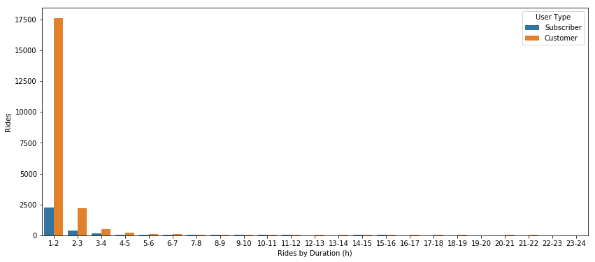

```python
plt.figure(figsize=[14, 6])

ax = sb.countplot(data=df_long, x='interval_h', hue='usertype')
ax.set_xlabel('Rides by Duration (h)')
ax.set_ylabel('Rides')
ax.legend(title='User Type');
```

It is clear that **most longer rides are taken by customers** and most of them are no more than 2 hours. This is reasonable due to the rental policy that day pass users can have unlimited access to bikes up to 2 hours in a 24-hour period.

Then I consider duration as a discrete numerical variable and plot a heatmap to see the relationship between duration and time of the day (hour).

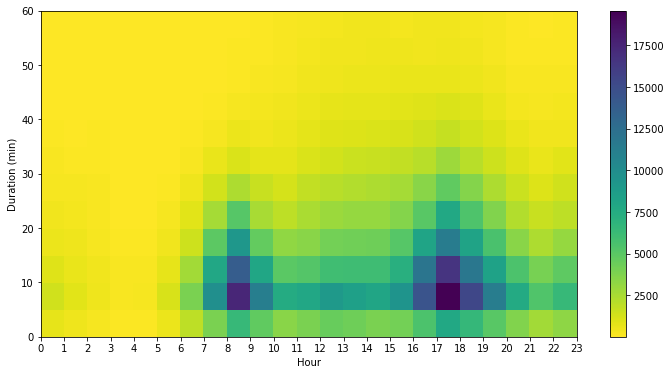

```python
# plot a heatmap for short rides
plt.figure(figsize=[12, 6])

xbin = np.arange(0, 24, 1)
ybin = np.arange(0, 64, 5)
plt.hist2d(data=df_short, x='hour', y='duration_min', bins=[xbin, ybin], cmap='viridis_r', cmin=0.5)
plt.colorbar()
plt.xticks(xbin)
plt.xlabel('Hour')
plt.ylabel('Duration (min)');
```

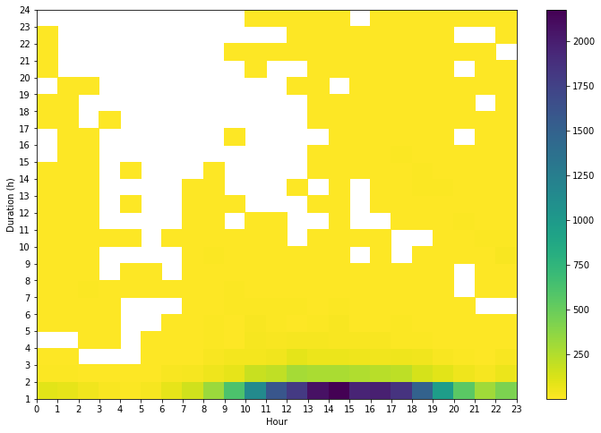

```python
# plot a heatmap for long rides
plt.figure(figsize=[12, 8])

xbin = np.arange(0, 24, 1)
ybin = np.arange(1, 25, 1)
plt.hist2d(data=df_long, x='hour', y='duration_h', bins=[xbin, ybin], cmap='viridis_r', cmin=0.5)
plt.colorbar()
plt.xticks(xbin)
plt.yticks(ybin)
plt.ylim(1, 24)
plt.xlabel('Hour')
plt.ylabel('Duration (h)');
```

I can see that **most short rides are taken during morning and evening peak hours and most long rides are taken in the afternoon**. I need to dig this result a little deeper by introducing user type in the next section.

### Talk about some of the relationships you observed in this part of the investigation. How did the feature(s) of interest vary with other features in the dataset?

My main findings are listed below:

1. The majority of subscribers were born in 80s and 90s while the majority of customers were born in 60s and 90s.
2. The majority of subscribers are male and there are more females than males among customers.
3. Subscribers use bikes more often during peak hours on weekdays while customers use bike more often in the afternoon on weekends. This can explain why the total bike use does not change dramatically over a week.
4. Subscribers usually take short rides around 5-10 minutes while customers prefer to take longer ride.

Based on the above analysis, I can profile subscribers and customers as:

- **Subscribers: male, born in 80s and 90s, commuters**
- **Customers: female > male, born in 60s and 90s, visitors**

### Did you observe any interesting relationships between the other features (not the main feature(s) of interest)?

I found that most short rides are taken during morning and evening peak hours and most long rides are taken in the afternoon. This pattern is very similar as subscribers' biking habits on weekdays versus customers' on weekends. I will further investigate this result in the next section.

## Multivariate Exploration

To further investigate the relationship between duraiton and hour by usertype and by weekday, I facet heatmaps of short rides as below.

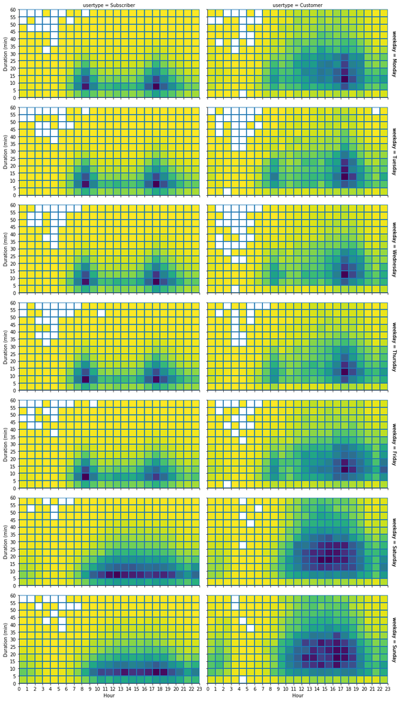

```python
df_short.rename(columns={'hour': 'Hour', 'duration_min': 'Duration (min)'}, inplace=True)

g = sb.FacetGrid(data=df_short, col='usertype', row='weekday', height=3, aspect=2, margin_titles=True)
xbin = np.arange(0, 24, 1)
ybin = np.arange(0, 65, 5)
g.map(plt.hist2d, 'Hour', 'Duration (min)', bins=[xbin, ybin], cmap='viridis_r', cmin=0.5)
g.set(xticks=xbin, yticks=ybin)
g.set_titles('{col_name}');
```

Using this chart, I now have a more thorough understanding of each user type's biking habits.

- Subscribers usually take short rides that last 5-15 minutes. Their biking habits differ between weekdays and weekends. On weekdays they use bikes more often during morning and evening peak hours while on weekends there is no obvious peak hour and they use bikes more often from 10am to 7pm.
- Customers' biking habits also differ on weekdays and weekends. On weekdays they prefer to take short rides (10-25 minutes) during evening peak hour while on weekends they prefer to take more longer rides (10-30 minutes) in the afternoon.

Now I want to use the existing data to predict a user's trip duration using multiple linear regression model.

```python
# create a weekday_weekend column
weekday = {'Monday': 'Weekday',
           'Tuesday': 'Weekday',
           'Wednesday': 'Weekday',
           'Thursday': 'Weekday',
           'Friday': 'Weekday',
           'Saturday': 'Weekend',
           'Sunday': 'Weekend'}
df['weekday_weekend'] = df['weekday']
df['weekday_weekend']= df['weekday_weekend'].map(weekday)
df.head(1)
```

|  | tripduration | starttime | stoptime | start_station_name | end_station_name | usertype | birth_year | gender | birth_decade | hour | weekday | duration_min | duration_h | route | weekday_weekend |
| --- | --- | --- | --- | --- | --- | --- | --- | --- | --- | --- | --- | --- | --- | --- | --- |
| 0 | 3363 | 2019-04-01 00:04:38.140 | 2019-04-01 01:00:41.639 | Union Square - Brighton Ave at Cambridge St | Union Square - Brighton Ave at Cambridge St | Customer | 1969 | Female | 1960s | 0 | Monday | 56 | 0 | Union Square - Brighton Ave at Cambridge St --... | Weekday |

```python
# create dummy variables of usertype and weekday_weekend
df[['subscriber', 'customer']] = pd.get_dummies(df['usertype'])
df[['weekday', 'weekend']] = pd.get_dummies(df['weekday_weekend'])
df.head(1)
```

|  | tripduration | starttime | stoptime | start_station_name | end_station_name | usertype | birth_year | gender | birth_decade | hour | weekday | duration_min | duration_h | route | weekday_weekend | subscriber | customer | weekend |
| --- | --- | --- | --- | --- | --- | --- | --- | --- | --- | --- | --- | --- | --- | --- | --- | --- | --- | --- |
| 0 | 3363 | 2019-04-01 00:04:38.140 | 2019-04-01 01:00:41.639 | Union Square - Brighton Ave at Cambridge St | Union Square - Brighton Ave at Cambridge St | Customer | 1969 | Female | 1960s | 0 | 1 | 56 | 0 | Union Square - Brighton Ave at Cambridge St --... | Weekday | 0 | 1 | 0 |

```python
# only include rides that are less than 3 hours
df_new = df[df['duration_h'] < 3]

# build a multiple linear regression model
df_new['intercept'] = 1
lm = sm.OLS(df_new['duration_min'], df_new[['intercept', 'subscriber', 'weekday']])
result = lm.fit()
result.summary()
```

OLS Regression Results

| Dep. Variable: | duration_min | R-squared: | 0.195 |
| --- | --- | --- | --- |
| Model: | OLS | Adj. R-squared: | 0.195 |
| Method: | Least Squares | F-statistic: | 8.020e+04 |
| Date: | Sun, 28 Jul 2019 | Prob (F-statistic): | 0.00 |
| Time: | 23:10:08 | Log-Likelihood: | -2.7646e+06 |
| No. Observations: | 661002 | AIC: | 5.529e+06 |
| Df Residuals: | 660999 | BIC: | 5.529e+06 |
| Df Model: | 2 |  |  |
| Covariance Type: | nonrobust |  |  |

|  | coef | std err | t | P>\|t\| | [0.025 | 0.975] |
| --- | --- | --- | --- | --- | --- | --- |
| intercept | 32.6858 | 0.047 | 693.890 | 0.000 | 32.593 | 32.778 |
| subscriber | -17.0344 | 0.047 | -361.339 | 0.000 | -17.127 | -16.942 |
| weekday | -3.5927 | 0.046 | -78.280 | 0.000 | -3.683 | -3.503 |

| Omnibus: | 439931.223 | Durbin-Watson: | 1.880 |
| --- | --- | --- | --- |
| Prob(Omnibus): | 0.000 | Jarque-Bera (JB): | 7820497.138 |
| Skew: | 2.978 | Prob(JB): | 0.00 |
| Kurtosis: | 18.763 | Cond. No. | 4.68 |

Warnings:  
[1] Standard Errors assume that the covariance matrix of the errors is correctly specified.

Only 19.5% of the variability in duration time can be explained by the linear model built using user type and weekday. I would expect that a subscriber's ride duration is 17 minutes less than a customer's when all else are equal; a weekday's ride duration is 4 minutes less than a weekend's, all else being equal. This is not a good example to apply regression model.

Finally, I want to see the average duration time by user type and by gender/birth decade.

```python
# create a function to create a DataFrame for heatmap
def heatmap_df(data, cat1, cat2, num):
    df = data.groupby([cat1, cat2]).mean()[num]
    df = df.reset_index(name='count')
    df = df.pivot(index=cat2, columns=cat1, values='count')
    return df
```

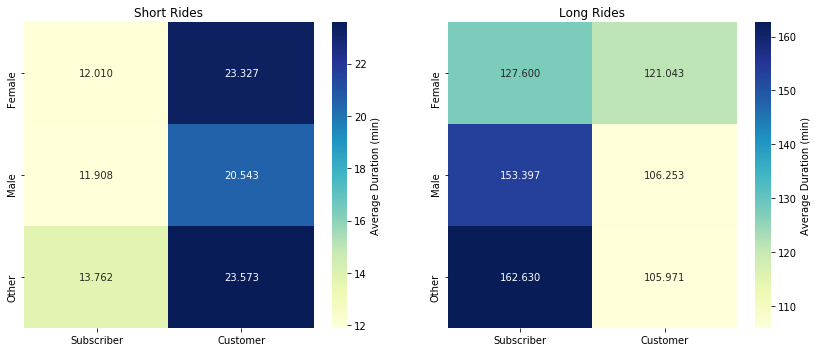

```python
plt.figure(figsize=[12, 5])

plt.subplot(1, 2, 1)
short = heatmap_df(df_short, 'usertype', 'gender', 'Duration (min)')
g = sb.heatmap(short, annot=True, fmt='.3f', cmap='YlGnBu', cbar_kws={'label': 'Average Duration (min)'})
g.set(xlabel='', ylabel='')
g.set_title('Short Rides')

plt.subplot(1, 2, 2)
long = heatmap_df(df_long, 'usertype', 'gender', 'duration_min')
g = sb.heatmap(long, annot=True, fmt='.3f', cmap='YlGnBu', cbar_kws={'label': 'Average Duration (min)'})
g.set(xlabel='', ylabel='')
g.set_title('Long Rides')

plt.subplots_adjust(wspace=12)
plt.tight_layout();
```

For short rides, the average trip duration of customers are longer than that of subscribers but there is no gender difference. For long rides, the average trip duration of subscribers are longer than that of customers and female customers have longer average trip duration than others.

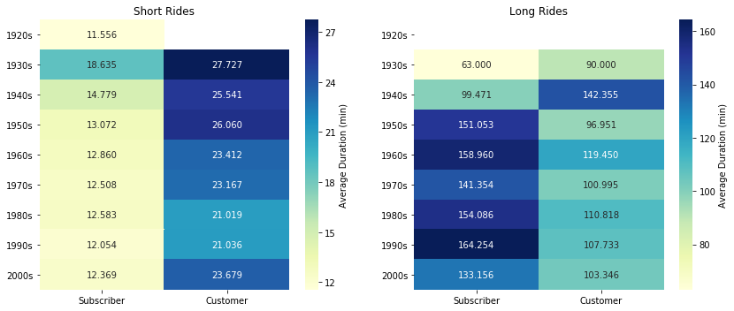

```python
plt.figure(figsize=[12, 5])

plt.subplot(1, 2, 1)
short = heatmap_df(df_short, 'usertype', 'birth_decade', 'Duration (min)')
g = sb.heatmap(short, annot=True, fmt='.3f', cmap='YlGnBu', cbar_kws={'label': 'Average Duration (min)'})
g.set(xlabel='', ylabel='')
g.set_title('Short Rides')

plt.subplot(1, 2, 2)
long = heatmap_df(df_long, 'usertype', 'birth_decade', 'duration_min')
g = sb.heatmap(long, annot=True, fmt='.3f', cmap='YlGnBu', cbar_kws={'label': 'Average Duration (min)'})
g.set(xlabel='', ylabel='')
g.set_title('Long Rides')

plt.subplots_adjust(wspace=2)
plt.tight_layout();
```

### Talk about some of the relationships you observed in this part of the investigation. Were there features that strengthened each other in terms of looking at your feature(s) of interest?

The faceted heatmaps show more information about the relationship between duration time and hour by user type and weekday. It helps me to understand each user type's biking habit more thoroughly. The result also reinforces my previous findings and conclusions.

- Subscribers' biking habits on weekdays differ from that on weekends. On weekdays, they take lots of short rides (5-15 minutes) during morning and evening peak hours. On weekends, they still take lots of short rides (5-15 minutes) but there is no obvious peak hour. They bikes often from 10am to 7pm.
- Customers' biking habits on weekdays also differ from that on weekends. On weekdays, they take lots of short rides (10-25 minutes) during evening peak hour. On weekends, they take longer rides (10-30 minutes) from 12pm to 7pm.

### Were there any interesting or surprising interactions between features?

According to the observations and conclusions above, my suggestions for Bluebikes would be:

- I can see that MIT students and employees who have a more discounted membership use Bluebikes more often. Bluebikes could partner with more local colleges and companies to provide discounted membership to attract more subscribers.
- Visitors are usually not familiar with the city and may not even know the service provided by Bluebikes. Bluebikes could design several classic biking routes for visitors to tour the most popular atractions. They could partner with CityPASS or other tourism programs to advertise their classic biking routes.